# Informe

Leonardo Santella | Simon Saman | Eloy Toro

Monday, August 10, 2015

1. Realice las tareas de pre-procesamiento necesarias para mejorar e identicar las palabras contenidas en cada post.

En principio cargamos los datos y las librerias necesarias

```r
library(tm)
library(FactoMineR)
setwd("~/Data Science/ProyectoICD")
data <- read.csv("data.csv", sep=";", row.names=1)
```

Para la limpieza de los datos consideramos las siguientes funciones definidas por nosotros

```r
#Esta funcion elimina caracteres seguidos, repetidos, de manera que hara mas eficiente el estudio.
#Forma una raiz para los diferentes tipos de risas escritas
#Forma un solo termino para la palabra video (elimina el plural "videos")
removeCharacters<- function(x){
  x<-gsub("aa+","a", x)
  x<-gsub("bb+]","b", x)
  x<-gsub("(cc)+c+","c", x)
  x<-gsub("dd+","d", x)
  x<-gsub("ee+","e", x)
  x<-gsub("ff+","f", x)
  x<-gsub("gg+","g", x)
  x<-gsub("hh+","h", x)
  x<-gsub("ii+","i", x)
  x<-gsub("jj+","j", x)
  x<-gsub("kk+","k", x)
  x<-gsub("(ll)+l+","l", x)
  x<-gsub("mm+","m", x)
  x<-gsub("nn+","n", x)
  x<-gsub("oo+","o", x)
  x<-gsub("pp+","p", x)
  x<-gsub("qq+","q", x)
  x<-gsub("rr+r+","r", x)
  x<-gsub("ss+","s", x)
  x<-gsub("tt+","t", x)
  x<-gsub("uu+","u", x)
  x<-gsub("vv+","v", x)
  x<-gsub("ww+","w", x)
  x<-gsub("xx+","x", x)
  x<-gsub("yy+","y", x)
  x<-gsub("zz+","z", x)
  x<-gsub("(jaja)+(ja)*", "haha", x)
  x<-gsub("(jeje)+(je)*", "haha", x)
  x<-gsub("(juju)+(ju)*", "haha", x)
  x<-gsub("(jojo)+(jo)*", "haha", x)
  x<-gsub("(hehe)+(he)*", "haha", x)
  x<-gsub("(haha)+(ha)*", "haha", x)
  x<-gsub("[jska]{6}[jska]*","haha",x)
  x<-gsub("[hsdg]{6}[hdgs]*","haha",x)
  x<-gsub("(xd)+","haha", x)
  x<-gsub("(lol)+[lo]*", "haha",x)
  x<-gsub("videos", "video", x)
  x
}

#Elimina iconos con codificacion UTF-8
removeUTFIcons <- function(x){
  gsub("<[[:alnum:]+[:alnum:]+]+>","",x)
}

#Elimina los numeros
removeNumbers <- function(x){
  gsub("[[:digit:]]", "", x)
}

#Elimina los caracteres individuales y los espacios en blanco al inicio del post
removeSingles <- function(x){
 x <- gsub("^.$","",x)
 x <- gsub("^.[[:space:]]$","",x)
 x <- gsub("^[[:space:]]", "", x)
 x
}

#Elimina los URL de los datos
removeURL <- function(x){
  x<-gsub("http[[:alnum:]]*", "", x)
  x<-gsub("www[[:alnum:]]*", "", x)
  x
}

#Inserta una fila en un data frame
insertRow <- function(existingDF, newrow, r) {
  existingDF[seq(r+1,nrow(existingDF)+1),] <- existingDF[seq(r,nrow(existingDF)),]
  existingDF[r,] <- newrow
  existingDF
}
```

Ahora procedemos a limpiar el set de datos, sin formar un corpus ya que de esta manera podemos observar de forma mas comoda el comportamiento de las acciones llevadas a cabo

```r
#Inicio Limpieza de datos

#Eliminamos las filas NA
data <- na.omit(data)

#Eliminamos la redundacia de espacios en blanco
data$post<-stripWhitespace(as.character(data$post))

#Elimina las filas que solo contienen un caracter no significativo
data<- data[!(is.na(data$post) | data$post=="" | data$post==" " | data$post=="\n" | data$post=="\v") | data$post=="\t" | data$post=="\r" | data$post=="\f",]

#Colocamos todas las letras en minuscula
data$post <- tolower(data$post)

#Removemos palabras no significativas para nuestro estudio
myStopwords <- c(stopwords(kind="es"), stopwords(kind='en'), 'mierda', 'verga', 'puta', 'fuck')
data$post <- removeWords(data$post, myStopwords)

#Eliminamos iconos codificados en UTF-8 (Algunos)
data$post <- removeUTFIcons(data$post)

#Eliminamos signos de puntuacion
data$post <- removePunctuation(data$post)

#Eliminaos los URL
data$post <- removeURL(data$post)

#Eliminamos por 2da vez la redundacia de espacios en blanco
data$post<-stripWhitespace(as.character(data$post))

#Eliminamos por 2da vez las filas que contienen catracteres no significativos
data<- data[!(is.na(data$post) | data$post=="" | data$post==" " | data$post=="\n" | data$post=="\v") | data$post=="\t" | data$post=="\r" | data$post=="\f",]

#Eliminamos varios elementos antes mencionados en la definicion de esta funcion
data$post <- removeCharacters(data$post)

#Eliminamos los numeros
data$post <- removeNumbers(data$post)

#Eliminamos caracteres individuales y espacios en blanco al inicio del post
data$post <- removeSingles(data$post)

#Eliminamos por ultima vez la redundancia de espacios en blanco
data$post<-stripWhitespace(as.character(data$post))

#Eliminamos las filas con caracteres no signuficativos
data<- data[!(is.na(data$post) | data$post=="" | data$post==" " | data$post=="\n" | data$post=="\v") | data$post=="\t" | data$post=="\r" | data$post=="\f",]
```

2. para cada individuo identifique las palabras que los relacionan con los otros.

Para determinar las palabras que relacionan a los usuarios entre ellos, debemos primero formar ciertas estructuras

```r
#Armamos 5 data frames, uno por usuario
postPersona1 <- data[data$id_user==1,]
postPersona2 <- data[data$id_user==2,]
postPersona3 <- data[data$id_user==3,]
postPersona4 <- data[data$id_user==4,]
postPersona5 <- data[data$id_user==5,]

#Armamos los corpus para luego armar las term-document matrix
corpus1 <- Corpus(VectorSource(postPersona1))
corpus2 <- Corpus(VectorSource(postPersona2))
corpus3 <- Corpus(VectorSource(postPersona3))
corpus4 <- Corpus(VectorSource(postPersona4))
corpus5 <- Corpus(VectorSource(postPersona5))

#Armamos las matrices respectivas
tdm1 <- TermDocumentMatrix(corpus1,control=list(wordLengths=c(2,Inf)))
tdm2 <- TermDocumentMatrix(corpus2,control=list(wordLengths=c(2,Inf)))
tdm3 <- TermDocumentMatrix(corpus3,control=list(wordLengths=c(2,Inf)))
tdm4 <- TermDocumentMatrix(corpus4,control=list(wordLengths=c(2,Inf)))
tdm5 <- TermDocumentMatrix(corpus5,control=list(wordLengths=c(2,Inf)))

#Extraemos los terminos de cada matriz
terminos1<- as.data.frame(unlist(findFreqTerms(tdm1, lowfreq=1)))
terminos2<- as.data.frame(unlist(findFreqTerms(tdm2, lowfreq=1)))
terminos3 <- as.data.frame(unlist(findFreqTerms(tdm3, lowfreq=1)))
terminos4 <- as.data.frame(unlist(findFreqTerms(tdm4, lowfreq=1)))
terminos5 <- as.data.frame(unlist(findFreqTerms(tdm5, lowfreq=1)))

#Calculamos la frecuencia de cada termino por usuario
termFrequency1 <- rowSums(as.matrix(tdm1))
termFrequency2 <- rowSums(as.matrix(tdm2))
termFrequency3 <- rowSums(as.matrix(tdm3))
termFrequency4 <- rowSums(as.matrix(tdm4))
termFrequency5 <- rowSums(as.matrix(tdm5))

#Inicializamos un data frame por usuario
Usuario1 <- data.frame( Termino=character(3700), frecuencia=numeric(3700))
Usuario2 <- data.frame( Termino=character(1545), frecuencia=numeric(1545))
Usuario3 <- data.frame( Termino=character(2800), frecuencia=numeric(2800))
Usuario4 <- data.frame( Termino=character(3222), frecuencia=numeric(3222))
Usuario5 <- data.frame( Termino=character(3282), frecuencia=numeric(3282))

#LLenamos los data frame
Usuario1$Termino <- terminos1[,1]
Usuario1$frecuencia <- termFrequency1
Usuario2$Termino <- terminos2[,1]
Usuario2$frecuencia <- termFrequency2
Usuario3$Termino <- terminos3[,1]
Usuario3$frecuencia <- termFrequency3
Usuario4$Termino <- terminos4[,1]
Usuario4$frecuencia <- termFrequency4
Usuario5$Termino <- terminos5[,1]
Usuario5$frecuencia <- termFrequency5

names(Usuario1)[2] <- paste("Usuario1")
names(Usuario2)[2] <- paste("Usuario2")
names(Usuario3)[2] <- paste("Usuario3")
names(Usuario4)[2] <- paste("Usuario4")
names(Usuario5)[2] <- paste("Usuario5")
rownames(Usuario1) <- Usuario1$Termino
rownames(Usuario2) <- Usuario2$Termino
rownames(Usuario3) <- Usuario3$Termino
rownames(Usuario4) <- Usuario4$Termino
rownames(Usuario5) <- Usuario5$Termino
Usuario1$Termino <- NULL
Usuario2$Termino <- NULL
Usuario3$Termino <- NULL
Usuario4$Termino <- NULL
Usuario5$Termino <- NULL


#Buscamos las relaciones entre los usuarios y obtemos subconjuntos de los data frames
#Relacion del Usuario 1 con los demas
Relacion12 <- merge(Usuario1, Usuario2, by = "row.names")
Relacion13 <- merge(Usuario1, Usuario3, by = "row.names")
Relacion14 <- merge(Usuario1, Usuario4, by = "row.names")
Relacion15 <- merge(Usuario1, Usuario5, by = "row.names")

#Relacion del usuario2 con los demas
Relacion21 <- merge(Usuario2, Usuario1, by = "row.names")
Relacion23 <- merge(Usuario2, Usuario3, by = "row.names")
Relacion24 <- merge(Usuario2, Usuario4, by = "row.names")
Relacion25 <- merge(Usuario2, Usuario5, by = "row.names")

#Relacion del usuario 3 con los demas
Relacion31 <- merge(Usuario3, Usuario1, by = "row.names")
Relacion32 <- merge(Usuario3, Usuario2, by = "row.names")
Relacion34 <- merge(Usuario3, Usuario4, by = "row.names")
Relacion35 <- merge(Usuario3, Usuario5, by = "row.names")

#Relacion del usuario 4 con el 5
Relacion45 <- merge(Usuario4, Usuario5, by = "row.names")

#Relacion del usuario 1 contra todos los demas
Relacion1vsT <- merge(Relacion12, Relacion13, all = TRUE)
Relacion1vsT <- merge(Relacion1vsT, Relacion14, all = TRUE)
Relacion1vsT <- merge(Relacion1vsT, Relacion15, all = TRUE)

#Relacion del usuario 2 contra todos los demas
Relacion2vsT <- merge(Relacion21, Relacion23, all = TRUE)
Relacion2vsT <- merge(Relacion2vsT, Relacion24, all = TRUE)
Relacion2vsT <- merge(Relacion2vsT, Relacion25, all = TRUE)

#Relacion del usuario 3 contra todos los demas
Relacion3vsT <- merge(Relacion31, Relacion32, all = TRUE)
Relacion3vsT <- merge(Relacion3vsT, Relacion34, all = TRUE)
Relacion3vsT <- merge(Relacion3vsT, Relacion35, all = TRUE)

#Relacion del usuario 4 contra todos los demas
Relacion4vsT <- merge(Relacion14,Relacion24, all = TRUE)
Relacion4vsT <- merge(Relacion4vsT, Relacion34, all = TRUE)
Relacion4vsT <- merge(Relacion4vsT, Relacion45, all = TRUE)

#Relacion del usuario 5 contra todos los demas
Relacion5vsT <- merge(Relacion15, Relacion25, all = TRUE)
Relacion5vsT <- merge(Relacion5vsT, Relacion35, all = TRUE)
Relacion5vsT <- merge(Relacion5vsT, Relacion45, all = TRUE)

#Relacion del de todos contra todos
#En este Data Frame podemos observar las palabras en las que se relacionan unos con otros
Relacion <- merge(Relacion1vsT, Relacion2vsT, all = TRUE)
Relacion <- merge(Relacion, Relacion3vsT, all = TRUE)
Relacion <- merge(Relacion, Relacion4vsT, all = TRUE)
Relacion <- merge(Relacion, Relacion5vsT, all = TRUE)
Relacion[is.na(Relacion)] <- 0
```

3. Aplique algun metodo de clasificacion para agrupar a los usuarios segun las palabras que elija.(justifque en el informe).

En este punto escogeremos ciertas palabras para clasificar los Usuarios segun lo que escriben en sus publicaciones

```r
corpus <- Corpus(VectorSource(data$post))
tdm <- TermDocumentMatrix(corpus,control=list(wordLengths=c(2,Inf)))
Terminos<- (unlist(findFreqTerms(tdm, lowfreq=1)))

allTerms = data.frame( Termino = character(10382), Frecuencia = numeric(10382))
allTerms$Termino <- (unlist(findFreqTerms(tdm, lowfreq=1)))
frecuenciaTotal <- rowSums(as.matrix(tdm))
allTerms$Frecuencia <- frecuenciaTotal

terminosFrecuentes <- allTerms[ allTerms$Frecuencia > 50, ]
rownames(terminosFrecuentes) <- terminosFrecuentes$Termino
terminosFrecuentes$Termino <- NULL
dim(terminosFrecuentes)
```

```
## [1] 40  1
```

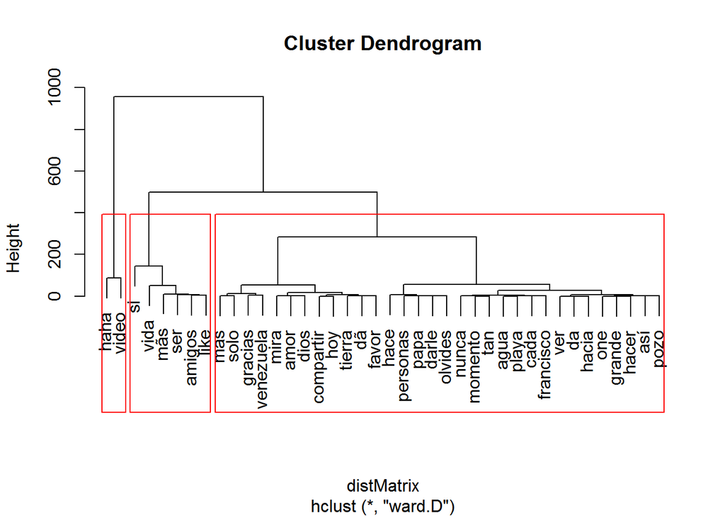

```r
distMatrix <- dist(terminosFrecuentes)
fit <- hclust(distMatrix, method="ward.D")
plot(fit)
rect.hclust(fit, k=3)
```

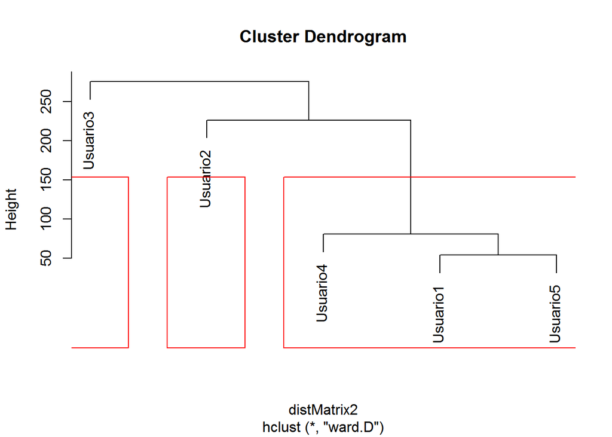

```r
#Formaremos 3 subgrupos de palabras frecuentes
grupos <- cutree(fit, k = 3)
terminosFrecuentes$Grupo <- grupos

aportes <- merge(terminosFrecuentes, Usuario1, all.x = TRUE, by = "row.names")
aportes <- merge(aportes, Usuario2, all.x = TRUE, by.x = "Row.names", by.y = "row.names")
aportes <- merge(aportes, Usuario3, all.x = TRUE, by.x = "Row.names", by.y = "row.names")
aportes <- merge(aportes, Usuario4, all.x = TRUE, by.x = "Row.names", by.y = "row.names")
aportes <- merge(aportes, Usuario5, all.x = TRUE, by.x = "Row.names", by.y = "row.names")
aportes[is.na(aportes)]<- 0

freqTerms <- findFreqTerms(tdm, lowfreq=50)
matrixClust <- aportes[c("Row.names","Usuario1", "Usuario2", "Usuario3", "Usuario4", "Usuario5")]
matrixClust <- t(matrixClust)
matrixClust <- matrixClust[2:6,]

distMatrix2 <- dist(matrixClust)
fit2 <- hclust(distMatrix2, method = "ward.D")
plot(fit2)
rect.hclust(fit2, k=3)
```

En el primer grafico podemos observar las palabras mas frecuentes, procederemos ahora a asignar clusters.

En el segundo podemos observar los clusters formados que por los usuarios segun su frecuencia aportada a las palabras mas frecuentes

Formamos 3 grupos caracterizamos las palabras por su frecuencia, el grupo 1 esta conformado por palabras que tienen una frecuencia mayor que 50 pero menor que 100, el grupo 2 mayor que 100 y menor que 222, el grupo 3 por elementos con frecuencia mayor que 222 y menor que 414.

Ahora clasificaremos a los usuarios por su aporte a la frecuencia de dichos terminos y observaremos las relaciones a traves de un analisis de componentes principales. La relacion esta dada por la frecuencia aportada por los usuarios a la frecuencia total de las palabras mas comunes en el total de publicaciones de la red social Facebook luego de limpiar la data.

```r
#Observaremos relaciones entre los usuarios
aportes
```

```
##    Row.names Frecuencia Grupo Usuario1 Usuario2 Usuario3 Usuario4 Usuario5
## 1       agua         59     1       12        2        0       44        1
## 2     amigos        123     2        9       90       13        5        6
## 3       amor         84     1        6        4       58       10        6
## 4        así         55     1       16       39        0        0        0
## 5       cada         60     1        7        1       42        4        6
## 6  compartir         76     1        8       59        1        3        5
## 7         da         52     1        2        2       30        5       13
## 8         dã         80     1        0        0       41       21       18
## 9      darle         65     1        5       34        7        4       15
## 10      dios         83     1        4       10       56        6        7
## 11     favor         79     1        4       59        9        4        3
## 12 francisco         61     1        1        0       59        1        0
## 13   gracias         88     1        5        3       62       14        4
## 14    grande         54     1        5       29       13        3        4
```

[output cut: 26 more lines]

```r
#Matriz de correlaciones
cor(aportes[,4:8])
```

```
##           Usuario1   Usuario2   Usuario3  Usuario4  Usuario5
## Usuario1 1.0000000  0.5261093  0.1138689 0.7991787 0.9162824
## Usuario2 0.5261093  1.0000000 -0.3706388 0.2524063 0.4861445
## Usuario3 0.1138689 -0.3706388  1.0000000 0.2264307 0.2196071
## Usuario4 0.7991787  0.2524063  0.2264307 1.0000000 0.8017538
## Usuario5 0.9162824  0.4861445  0.2196071 0.8017538 1.0000000
```

```r
#Analisis de componentes principales
componentes <- PCA(aportes[, 4:8])
```

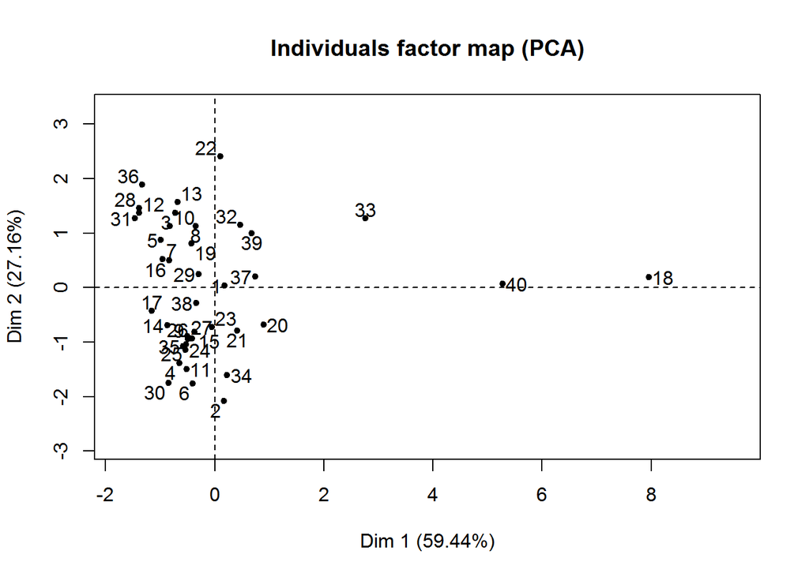

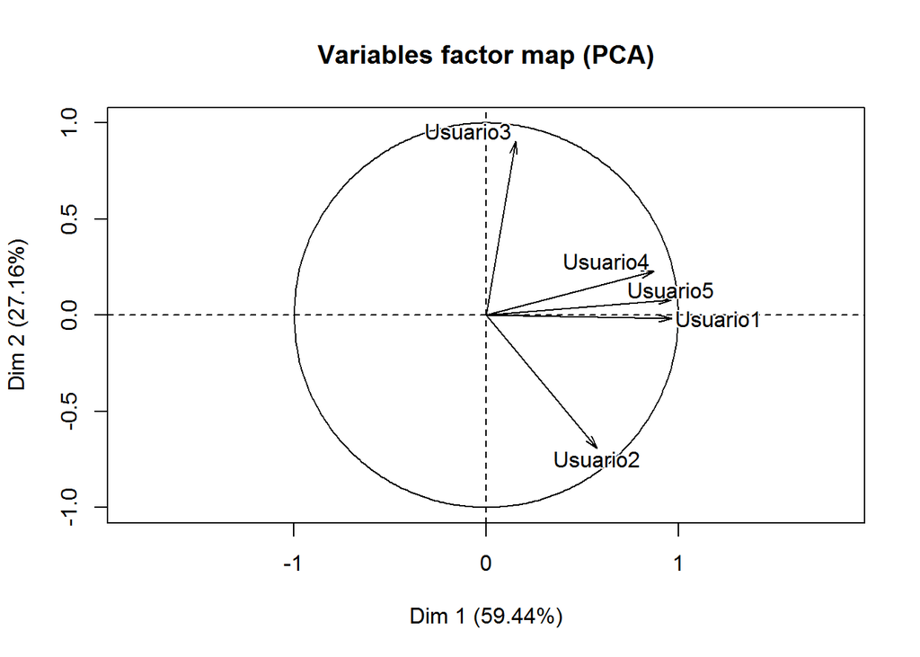

En el Data Frame anterior podemos observar la frecuencia de los terminos mas comunes (frecuencia > 50) y el aporte de a dicha frecuencia por parte de cada usuario.

```r
Grupo1 <- aportes[aportes$Grupo==1,]
Grupo2 <- aportes[aportes$Grupo==2,]
Grupo3 <- aportes[aportes$Grupo==3,]

Grupo1
```

```
##    Row.names Frecuencia Grupo Usuario1 Usuario2 Usuario3 Usuario4 Usuario5
## 1       agua         59     1       12        2        0       44        1
## 3       amor         84     1        6        4       58       10        6
## 4        así         55     1       16       39        0        0        0
## 5       cada         60     1        7        1       42        4        6
## 6  compartir         76     1        8       59        1        3        5
## 7         da         52     1        2        2       30        5       13
## 8         dã         80     1        0        0       41       21       18
## 9      darle         65     1        5       34        7        4       15
## 10      dios         83     1        4       10       56        6        7
## 11     favor         79     1        4       59        9        4        3
## 12 francisco         61     1        1        0       59        1        0
## 13   gracias         88     1        5        3       62       14        4
## 14    grande         54     1        5       29       13        3        4
## 15      hace         71     1       15       33       11        5        7
```

[output cut: 18 more lines]

```r
Grupo2
```

```
##    Row.names Frecuencia Grupo Usuario1 Usuario2 Usuario3 Usuario4 Usuario5
## 2     amigos        123     2        9       90       13        5        6
## 20      like        119     2       17       38       12       15       37
## 22       mãs        128     2        0        0       79       30       19
## 32       ser        115     2       24        7       47       24       13
## 33        si        222     2       43       33       63       35       48
## 39      vida        156     2       13       38       65       23       17
```

```r
Grupo3
```

```
##    Row.names Frecuencia Grupo Usuario1 Usuario2 Usuario3 Usuario4 Usuario5
## 18      haha        414     3      101       87       49       73      104
## 40     video        326     3       58       83       52       51       82
```

```r
summary(Grupo1)
```

```
##   Row.names           Frecuencia        Grupo      Usuario1
##  Length:32          Min.   :52.00   Min.   :1   Min.   : 0.000
##  Class :AsIs        1st Qu.:56.75   1st Qu.:1   1st Qu.: 3.500
##  Mode  :character   Median :64.50   Median :1   Median : 6.500
##                     Mean   :68.47   Mean   :1   Mean   : 7.281
##                     3rd Qu.:79.25   3rd Qu.:1   3rd Qu.:11.250
##                     Max.   :98.00   Max.   :1   Max.   :20.000
##     Usuario2        Usuario3        Usuario4         Usuario5
##  Min.   : 0.00   Min.   : 0.00   Min.   : 0.000   Min.   : 0.000
##  1st Qu.: 2.00   1st Qu.: 2.75   1st Qu.: 3.000   1st Qu.: 3.000
##  Median :18.50   Median :11.50   Median : 5.500   Median : 6.000
##  Mean   :21.25   Mean   :23.25   Mean   : 9.031   Mean   : 7.656
##  3rd Qu.:34.25   3rd Qu.:41.25   3rd Qu.:12.000   3rd Qu.:13.500
##  Max.   :61.00   Max.   :76.00   Max.   :44.000   Max.   :21.000
```

```r
summary(Grupo2)
```

```
##   Row.names           Frecuencia        Grupo      Usuario1
##  Length:6           Min.   :115.0   Min.   :2   Min.   : 0.00
##  Class :AsIs        1st Qu.:120.0   1st Qu.:2   1st Qu.:10.00
##  Mode  :character   Median :125.5   Median :2   Median :15.00
##                     Mean   :143.8   Mean   :2   Mean   :17.67
##                     3rd Qu.:149.0   3rd Qu.:2   3rd Qu.:22.25
##                     Max.   :222.0   Max.   :2   Max.   :43.00
##     Usuario2        Usuario3       Usuario4       Usuario5
##  Min.   : 0.00   Min.   :12.0   Min.   : 5.0   Min.   : 6.00
##  1st Qu.:13.50   1st Qu.:21.5   1st Qu.:17.0   1st Qu.:14.00
##  Median :35.50   Median :55.0   Median :23.5   Median :18.00
##  Mean   :34.33   Mean   :46.5   Mean   :22.0   Mean   :23.33
##  3rd Qu.:38.00   3rd Qu.:64.5   3rd Qu.:28.5   3rd Qu.:32.50
##  Max.   :90.00   Max.   :79.0   Max.   :35.0   Max.   :48.00
```

```r
summary(Grupo3)
```

```
##   Row.names           Frecuencia      Grupo      Usuario1
##  Length:2           Min.   :326   Min.   :3   Min.   : 58.00
##  Class :AsIs        1st Qu.:348   1st Qu.:3   1st Qu.: 68.75
##  Mode  :character   Median :370   Median :3   Median : 79.50
##                     Mean   :370   Mean   :3   Mean   : 79.50
##                     3rd Qu.:392   3rd Qu.:3   3rd Qu.: 90.25
##                     Max.   :414   Max.   :3   Max.   :101.00
##     Usuario2     Usuario3        Usuario4       Usuario5
##  Min.   :83   Min.   :49.00   Min.   :51.0   Min.   : 82.0
##  1st Qu.:84   1st Qu.:49.75   1st Qu.:56.5   1st Qu.: 87.5
##  Median :85   Median :50.50   Median :62.0   Median : 93.0
##  Mean   :85   Mean   :50.50   Mean   :62.0   Mean   : 93.0
##  3rd Qu.:86   3rd Qu.:51.25   3rd Qu.:67.5   3rd Qu.: 98.5
##  Max.   :87   Max.   :52.00   Max.   :73.0   Max.   :104.0
```

En los datos anteriores se puede observar los usuarios que mas aportan a una palabra en un determinado grupo, por ejemplo el Usuario2 aporta 90 de la frecuencia total de una palabra, el Usuario 5 en el grupo 3 aporta 104 y el Usuario3 en el grupo 1 aporta 76 a una palabra. Dichas palabras de pueden observar en los Data Frame antes mostrados con los elementos de los grupos

4. Genere un nuevo data frame en el que almacene una matriz individuos* individuos y cada entrada son las palabras que los relacionan, luego guardelo en un nuevo archivo con el nombre CI1 CI2 facebook usuarios grupos.csv

```r
write.csv(Relacion, "21014872_22022441_23194702_facebook_usuarios_grupos.csv")
```

5. Define las relaciones que considere mas importantes.

En este punto es importante destacar que que existen usuarios que aportan casi toda la frecuencia total a ciertas palabras, en funcion a esto, podemos llegar a la conclusion que estos usuarios se diferencian de los demas, debido a que en sus Facebooks, hablan mucho mas de topicos relacionados con dicha palabra que los otros usuarios.

```r
aportes
```

```
##    Row.names Frecuencia Grupo Usuario1 Usuario2 Usuario3 Usuario4 Usuario5
## 1       agua         59     1       12        2        0       44        1
## 2     amigos        123     2        9       90       13        5        6
## 3       amor         84     1        6        4       58       10        6
## 4        así         55     1       16       39        0        0        0
## 5       cada         60     1        7        1       42        4        6
## 6  compartir         76     1        8       59        1        3        5
## 7         da         52     1        2        2       30        5       13
## 8         dã         80     1        0        0       41       21       18
## 9      darle         65     1        5       34        7        4       15
## 10      dios         83     1        4       10       56        6        7
## 11     favor         79     1        4       59        9        4        3
## 12 francisco         61     1        1        0       59        1        0
## 13   gracias         88     1        5        3       62       14        4
## 14    grande         54     1        5       29       13        3        4
```

[output cut: 26 more lines]

Se puede observar como por ejemplo el usuario 3 abarca gran parte de la frecuencia de las palabras “dios”, “papa”, “francisco”. Por lo cual podemos inferir que el Usuario3 esta relacionado con la relacion Cristiana, siendo su maximo representante en la tierra (que tambien es un termino en el cual aporta gran parte de la frecuencia total) el papa Francisco.

Se puede observar ademas, que los usuario 1,2 y 5 son los que mas aportan al grupo 3 del cluster de palabras, formado por las palabras “haha” de frecuencia 414 y la palabra video de frecuencia 326.

Una relacion importante, es que todos los usuarios estan fuertementes relacionados por las palabras haha y video. En base a esto, se puede concluir que los amigos de los diferentes usuarios, tienden a “escribir” su risa y publicar videos (o hablar de ellos) de manera regular en la red social facebook.